# Assignment 1: Eulerian Video Magnification

Fall 2025 AI621 Computational Image Generation and Manipulation

- **Name** : Bushra Monika HOSSAIN
- **Student Number**: 20256306

## 1. Overview

Eulerian Video Magnification (EVM) is a method first introduced by researchers at MIT (Wu et al., 2012) to reveal subtle variations in videos that are invisible to the human eye.  
Instead of explicitly tracking motion, EVM decomposes a video spatially into a Laplacian pyramid, then applies temporal filtering to magnify small changes in intensity or color.  
This allows us to “see the unseen”: for example, tiny motions of a baby’s chest during breathing, or subtle color variations in the skin due to blood flow.

The figure below (credit: MIT, Wu et al., 2012) shows the principle of EVM:

1. **Spatial Decomposition**: The video is decomposed into different spatial frequency bands.
2. **Temporal Processing**: Each band is filtered in time to isolate a frequency range of interest (e.g. heartbeat or breathing rate).
3. **Amplification and Reconstruction**: The filtered signal is amplified and added back to reconstruct a video where the subtle changes are now visible.

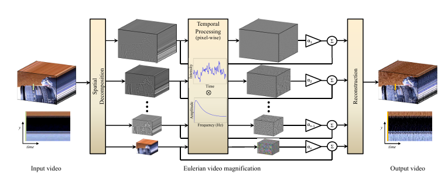

In this assignment, we reproduced the original paper’s results on two provided sequences:

- **face.mp4**: color amplification of subtle blood flow (IQ channels).
- **baby2.mp4**: motion amplification of subtle breathing movements (Y channel, high-frequency band).

For the custom experiment, we recorded a simple video of a **cup of coffee**.  
While the original idea was to reveal micro-vibrations of the liquid surface, the result mostly produced amplified contrast patterns in the form of light/dark fluctuations, almost like shadow and sunlight moving across the cup.  
This highlights a limitation of the method: when the signal-to-noise ratio is very low, the amplification can emphasize artifacts or lighting variations instead of true physical motion.

The goal of this project is not only to reproduce the published results, but also to explore the potential and limitations of Eulerian Video Magnification when applied to different kinds of videos.

## 2. Implementation Details

#### 2.1 Color Transformation

Here, the frames are converted from RGB to YIQ.

- Y is for luminance, used for motion amplification
- I/Q is for chrominance, used for color amplification. We seperate them to target motion or color changes independently.

```python
RGB_to_YIQ = np.array([
    [0.299,  0.587,  0.114],
    [0.596, -0.274, -0.322],
    [0.211, -0.523,  0.312]
], dtype=np.float32)
YIQ_to_RGB = np.linalg.inv(RGB_to_YIQ).astype(np.float32)

def rgb2yiq(frames_rgb):
    T, H, W, _ = frames_rgb.shape
    fr = frames_rgb.reshape(-1, 3)
    yiq = fr @ RGB_to_YIQ.T
    return yiq.reshape(T, H, W, 3)

def yiq2rgb(frames_yiq):
    T, H, W, _ = frames_yiq.shape
    fr = frames_yiq.reshape(-1, 3)
    rgb = fr @ YIQ_to_RGB.T
    return np.clip(rgb.reshape(T, H, W, 3), 0.0, 1.0)
```

#### 2.2 Laplacian Pyramid

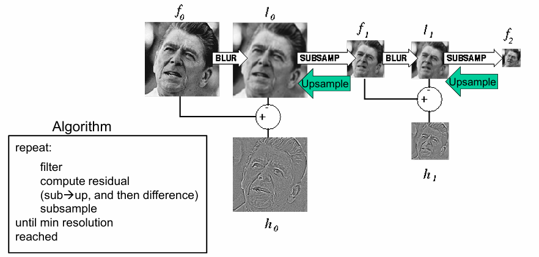

In this step, each frame is decomposed into a multi-level Laplacian pyramid. We skipped the finest level later during amplification, because it often contains noise.

```python
def build_video_pyramid(frames, levels):

    T, H, W, C = frames.shape
    print(f"[INFO LOG] Laplacian pyramid: {T} frames, {H}x{W}, {C} channels")


    pyramid = [[] for _ in range(levels)]

    for t in range(T):
        # building gaussian pyramid for this frame
        gaussian = [frames[t]]
        for _ in range(1, levels):
            gaussian.append(cv2.pyrDown(gaussian[-1]))

        # Laplacian levels = gaussian - upsample
        for l in range(levels - 1):
            up = cv2.pyrUp(gaussian[l + 1], dstsize=(gaussian[l].shape[1], gaussian[l].shape[0]))
            lap = gaussian[l] - up
            pyramid[l].append(lap)

        # last levels
        pyramid[-1].append(gaussian[-1])


    return [np.stack(level, axis=0) for level in pyramid]
```

### 2.3 Temporal Filtering

A Butterworth band-pass filter isolates the desired frequency range (heartbeat, breathing or subtle surface motion).

```python
def temporal_bandpass_filter(data, fps, f_low, f_high, alpha=1.0, order=1):
    nyquist = fps / 2
    b, a = butter(order, [f_low / nyquist, f_high / nyquist], btype="band")
    bandpassed = filtfilt(b, a, data, axis=0)
    return data + alpha * bandpassed
```

#### 2.4 Frequency Band Selection

In the original paper by Wu et al. (MIT, 2012), the authors provide a table of suggested parameters (amplification factor α, spatial cutoff λc, and frequency bands ωl–ωh) for different test videos, such as *face*, *baby*, *subway*, *guitar*, etc.

For example, their **Table 1** (below) shows values of α and frequency ranges used to highlight either color changes or subtle motions:

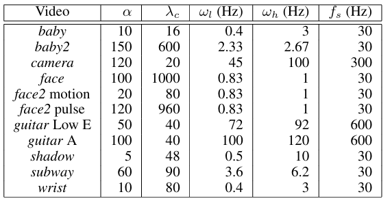

In our implementation, we selected parameters inspired by the paper but adapted to our videos:

[output not shown]

But Band selection was too critical:

- Too wide → noise and unrelated motions are amplified.
- Too narrow → risk of missing the signal of interest.

#### 2.5 Image Reconstruction

Finally, the pyramid is collapsed from top to bottom by upsamplid and adding Laplacian levels.

```python
def collapse_laplacian_pyramid(pyramid_levels):

    levels = len(pyramid_levels)
    T = pyramid_levels[0].shape[0]
    recon = []

    for t in range(T):
        frame = pyramid_levels[-1][t]
        for l in range(levels - 2, -1, -1):
            target_size = (pyramid_levels[l][t].shape[1], pyramid_levels[l][t].shape[0])
            frame = cv2.pyrUp(frame, dstsize=target_size) + pyramid_levels[l][t]
        recon.append(frame)

    return np.stack(recon, axis=0)
```

### 2.6 ROI Signal Analysis (Baby2)

To further analyze the baby2 sequence, we extracted the average intensity signal from a selected **ROI** (region of interest) around the baby’s chest.  
The idea is to track subtle periodic variations in the Y channel (luminance), which correspond to breathing or heartbeat activity.

The code below shows the two functions we used:

[figure not shown]

```python
def extract_roi_signal(frames_yiq, roi, channel=0):
    x, y, w, h = roi
    roi_area = frames_yiq[:, y:y+h, x:x+w, channel]
    return roi_area.mean(axis=(1, 2))


def analyze_roi_signal(signal, fps, band, title="ROI signal"):
    nyquist = fps / 2
    b, a = butter(1, [band[0] / nyquist, band[1] / nyquist], btype="band")
    filtered = filtfilt(b, a, signal)

    # FFT
    T = len(filtered)
    freqs = np.fft.fftfreq(T, d=1.0 / fps)
    spectrum = np.abs(np.fft.fft(filtered - np.mean(filtered)))

    # dominant frequency
    mask = (freqs > band[0]) & (freqs < band[1])
    peak_freq = freqs[mask][np.argmax(spectrum[mask])] if np.any(mask) else 0.0
    bpm = peak_freq * 60.0

    #plots
    t = np.arange(T) / fps
    plt.figure(figsize=(12, 4))
    plt.subplot(1, 2, 1)
    plt.plot(t, filtered)
    plt.title(f"{title} ({band[0]:.2f}-{band[1]:.2f} Hz)")
    plt.xlabel("Time (s)"); plt.ylabel("Amplitude")

    plt.subplot(1, 2, 2)
    plt.plot(freqs[:T // 2], spectrum[:T // 2])
    plt.title(f"Spectrum • peak ≈ {bpm:.1f} bpm")
    plt.xlabel("Frequency (Hz)"); plt.ylabel("Amplitude")
    plt.xlim(0, max(5, band[1] * 2))
    plt.tight_layout()
    plt.show()

    print(f"[RESULT LOG] Estimated peak: {bpm:.1f} bpm")
```

Here we analyzed a small region on the baby’s chest to check if the amplified motion really corresponds to breathing.

- **Left (Time domain):**  
  The signal over time shows clear up-and-down oscillations, which match the chest movement as the baby breathes.
- **Right (Frequency domain):**  
  The spectrum has a strong peak around 2.5 Hz, which is about **150 bpm**.  
  This value makes sense because newborns typically breathe very fast compared to adults.

**Result:**  
This confirms that the motion we amplified is not random noise, but the baby’s actual breathing pattern.

### 2.7 Main script

```python
data_path = "./data/"
output_path = "./output/"
video_files = ['face.mp4', 'baby2.mp4', 'coffee.mp4']

os.makedirs(output_path, exist_ok=True)

for video_name in video_files:
    print(f"\nBegin processing video {video_name}")
    video_path = os.path.join(data_path, video_name)

    # load frames and convert to YIQ color space
    frames, fps = load_video_frames(video_path)
    frames_yiq = rgb2yiq(frames)

    # set parameters depending on the video
    if "face" in video_name:
        band = (0.83, 1.0); alpha, channel, levels = 100.0, "IQ", 4
    elif "baby2" in video_name:
        band = (2.33, 2.67); alpha, channel, levels = 150.0, "Y", 4
    elif "coffee" in video_name:
        band = (0.2, 0.5); alpha, channel, levels = 130.0, "Y", 5
    else:
        band = (0.4, 3.0); alpha, channel, levels = 50.0, "Y", 4

    print(f"[PARAMS] band={band[0]}-{band[1]} Hz | α={alpha} | channel={channel} | levels={levels}")

    # plot ROI signal
    if "baby2" in video_name:
        roi = (200, 100, 50, 50)
        sig = extract_roi_signal(frames_yiq, roi, channel=0)
        analyze_roi_signal(sig, fps, band, title="baby2 ROI (Y)")

    # build Laplacian pyramid
    video_pyr = build_video_pyramid(frames_yiq, levels=levels)

    filtered_pyr = []
    for lvl, lvl_data in enumerate(video_pyr):

        # we can skip the finest level (less noise)
        if lvl < 1:
            filtered_pyr.append(lvl_data)
            continue

        Y, IQ = lvl_data[..., 0:1], lvl_data[..., 1:3]

        if channel == "Y":
            # special case for coffee because of noise: inject filtered signal instead of replacing Y
            if "coffee" in video_name:
                Y_filt = temporal_bandpass_filter(Y, fps, band[0], band[1], alpha, order=1)
                Y = Y + (Y_filt - Y) * 0.8
                IQ *= 1.0
            else:
                Y = temporal_bandpass_filter(Y, fps, band[0], band[1], alpha, order=1)
                IQ *= 0.8
        else:
            # amplify IQ only (used for face.mp4)
            IQ = temporal_bandpass_filter(IQ, fps, band[0], band[1], alpha, order=1)

        lvl_out = np.concatenate([Y, IQ], axis=-1)

        # apply spatial blur (stronger for coffee)
        ksize = (9, 9) if "coffee" in video_name else (5, 5)
        lvl_out = np.stack([cv2.GaussianBlur(f, ksize, 0) for f in lvl_out], axis=0)

        filtered_pyr.append(lvl_out)

    # collapse pyramid to reconstruct video
    recon_yiq = collapse_laplacian_pyramid(filtered_pyr)


    recon_rgb = yiq2rgb(recon_yiq)
    out_path = os.path.join(output_path, f'output_{video_name}')
    save_video(recon_rgb, fps, out_path)

    print(f"Saved {out_path}")
    print(f"End processing video {video_name}")
```

## 3. Results

#### Face Sequence

```python
# Check data\face.mp4 for the sequence
```

In the face sequence, we can clearly observe periodic **color pulsations** on the subject’s skin.  
At times the face looks slightly green/yellow, then it shifts towards red, simulating the blood flow.  
These subtle changes, invisible to the naked eye, are now amplified and visible in rhythm with the heartbeat.

#### Baby2 Sequence

```python
# Check data\baby2.mp4 for the sequence
```

In the baby2 sequence, the chest and surrounding area show **exaggerated breathing motion**.  
The subtle rise-and-fall, which is normally imperceptible, appears much stronger after amplification.  
The motion looks fast because we selected the high-frequency band (~2.5 Hz) as suggested in the paper.

#### Custom Video: Coffee Sequence

```python
# Check data\coffee.mp4 for the sequence
```

For the custom coffee sequence, the algorithm produced strong **dark/light fluctuations** around the edges of the cup.  
Instead of clear ripples on the liquid surface, the result appears more like shadow/contrast variations.  
This highlights a limitation of EVM: when the signal is weak, amplification may enhance noise or lighting artifacts rather than the intended motion.

## 4. Discussion

During this assignment, several difficulties were encountered:

- **Memory and performance issues:**  
  When running the code on Google Colab, the notebook often crashed due to RAM limits.  
  Processing the Laplacian pyramid across all frames is memory intensive.  
  Switching to VSCode on a local machine with 16 GB RAM was sufficient to run the experiments smoothly.
- **Noise amplification:**  
  A major challenge was controlling the noise.  
  At first, amplification produced strong artifacts, especially on fine pyramid levels.  
  I had to carefully tune the number of pyramid levels, apply Gaussian blur, and adjust α values to reduce these artifacts.  
  Even then, the baby sequence appeared somewhat blurry after magnification.
- **Baby sequence limitations:**  
  Although the motion amplification worked, the result was not as visually clear as expected.  
  The chest movement was visible, but the baby’s face remained almost static.  
  I would have liked to also see subtle color pulsations (face turning slightly red with heartbeat), even if this was not part of the assignment.
- **Custom coffee sequence:**  
  For the coffee experiment, I expected to reveal micro-vibrations of the liquid surface.  
  Instead, the output mainly showed contrast and shadow-like changes, not real ripples.  
  This demonstrates one of the limitations of Eulerian Video Magnification: when the signal-to-noise ratio is very low, the algorithm can amplify lighting variations or noise rather than actual physical motion.

  This observation is consistent with what is discussed in the original MIT paper (Wu et al., 2012):  
  EVM only works well when there is a measurable signal within the chosen frequency band.  
  If the true motion is extremely weak, the algorithm ends up amplifying noise, compression artifacts, or lighting variations instead of real motion.

In my case (coffee sequence), the liquid surface was almost perfectly still, so the signal-to-noise ratio was very low.  
As a result, the method amplified mostly contrast and illumination changes, which explains why I obtained shadow-like effects rather than the subtle ripples I was expecting.

Finally, the assignment was a good exercise in understanding how Eulerian Video Magnification works in practice.  
It also showed that the method requires careful parameter tuning (band selection, α, and pyramid depth) to balance between amplifying real signals and avoiding artifacts.

## 5.Extras (Bonus)

For the bonus part of the assignment, I experimented with my own custom video: a simple **cup of coffee**.  
The motivation was to test Eulerian Video Magnification on an everyday object, to see if subtle surface vibrations of the liquid could be revealed.

**Expectations:**  
I expected to see the coffee surface “ripple” slightly, revealing vibrations that are not visible to the naked eye.

**Results:**  
Instead of clear ripples, the magnification mainly produced **contrast and shadow-like patterns** around the cup.  
This was different from what I had imagined, but it still showed how EVM reacts when the true motion signal is extremely weak.  
In this case, the method amplified mostly noise or lighting variations rather than real surface motion.

**Main Conclusion:**  
Although the visual result was not as compelling as the face or baby sequences, it was still interesting to test EVM on a completely new scenario.  
This highlighted both the **potential** (EVM can, in theory, reveal invisible micro-motions) and the **limitations** (sensitivity to noise and lighting conditions) of the technique.

```python
!python -m nbconvert --to html Report_Assignment_1.ipynb
```

```
[NbConvertApp] Converting notebook Report_Assignment_1.ipynb to html
[NbConvertApp] Writing 22635638 bytes to Report_Assignment_1.html
```